# hw4-Sangwon-Ji

2022-10-23

## 1) Future Value

Function future_value

$FV = P(1 +{\frac{r}{k}}))^{nk}$

- FV= future value
- P= principal
- r= annual interest rate
- n= number of years
- k = number of compounding periods per year

#### 1.1) Function future_value

```r
future_values = function(principal= 1, r= 0.01, k= 1, n=1) {
value = principal * (1+(r/k)) ^ (n*k)
return(value)
}

future_values(principal=1000, r =0.02, k=1, n=2)
```

```
## [1] 1040.4
```

- By end of 2 years, I would have 1040.4 dollars.

#### 1.2) Use future_value() to answer the following question

Paul deposits $1,000 in a Certificate of Deposit for 3 years at 2.5% per year compounded annually. What will be the value of the money at the end of 3 years?

```r
future_values(principal=1000, r=0.025, k=1, n=3)
```

```
## [1] 1076.891
```

- Paul would have 1076.89 dollars at the end of three years.

## 2) Future Value of Ordinary Annuity

Future Value of an ordinary Annuity formula:

$FVordinary annuity \rightarrow FV = PMT {\times} {\frac{(1 + {\frac{r}{k}})^{nk} - 1}{^r/_k}}$

if r = 0 then :

$FV = PMT \times nk$

- FV= future value
- PMT= periodic contribution made at the end of each period
- r= annual interest rate
- n= number of years
- k= number of compounding periods per year

#### 2.1) Function annuity()

```r
annuity = function(PMT= 1, r= 0.01, k= 1, n=1) {
if (r >0) {
  FV = PMT * (((1+ r/k) ^ (n*k) - 1) / (r/k))
} else {
   FV = PMT * (n *k)
}
  return(FV)
}
```

#### 2.2) Use your function annuity() to find how much money Mrs. Savingswood will have at the end of 10 years.

```r
annuity(PMT=100, r = 0.05, k=12, n=10)
```

```
## [1] 15528.23
```

- Mrs. Savingswood will have 15528.23 at the end of 10 years.

## 3) Combo: Future Value and ordinary Annuity

The formula:

$FV = P(1 +{\frac{r}{k}})^{nk} + PMT{\frac{(1 + {\frac{r}{k}})^{nk} - 1}{^r/_k}}$

#### 3.1) Investment table for a 10-year period

```r
initial_amount = 1000
num_years = 10
annual_contributions = 720
return_rates = 0.0755
set.seed(12345)

Amount = rep(initial_amount, length = num_years + 1)

for (year in 0:num_years) {
  Amount[year+1] = future_values(p=1000, r= 0.0755, k=1, year) + annuity(PMT =720, r = 0.0755, k=1, year)
}

years = c(0:10)

balance.df <- data.frame(years, Amount)
balance.df
```

```
##    years    Amount
## 1      0  1000.000
## 2      1  1795.500
## 3      2  2651.060
## 4      3  3571.215
## 5      4  4560.842
## 6      5  5625.186
## 7      6  6769.887
## 8      7  8001.014
## 9      8  9325.090
## 10     9 10749.134
## 11    10 12280.694
```

## 4) Simulating Investing in a Total Stock Market index fund

- We are going to assume that annual rates of return $r_y$ follow a **normal distribution** with a mean $\mu=10$% and a standard deviation $\sigma= 18$%

$r_y∼N(\mu=10$%$,\sigma=18$%)

#### 4.1) 50 simulations of a 10-year investment period

```r
initial_amount = 1000
num_years = 10
num_simulations =50
annual_return = 0.1
annual_volatility = 0.18
set.seed(12345)

balances = matrix(0, nrow= num_years+1, ncol = num_simulations)

for (sim in 1:num_simulations) {
  aux_balance = rep(initial_amount, num_years + 1)
  return_rates = rnorm(num_years, mean =annual_return, sd =annual_volatility)
  for (year in 1:num_years) {
    aux_balance[year + 1] = aux_balance[year] * (1+return_rates[year]) + 360
  }
  balances[ ,sim] = aux_balance
  }

rownames(balances) = 0:num_years
colnames(balances) =paste0("sim", 1:num_simulations)
balances.df <- data.frame(balances)
balances.df %>% select(1:3)
```

```
##        sim1      sim2     sim3
## 0  1000.000  1000.000 1000.000
## 1  1565.395  1439.075 1600.332
## 2  2281.842  2413.728 2539.718
## 3  2825.132  3176.128 2859.136
## 4  3237.031  4151.150 2705.736
## 5  4273.764  4365.462 2558.173
## 6  3662.627  5803.914 4005.186
## 7  4804.297  5818.324 4418.469
## 8  5405.890  6412.896 5713.719
## 9  6029.975  8707.848 7274.641
## 10 5995.144 10406.856 8149.569
```

#### Converting, Building Data frame

```r
balances_df = as.data.frame(balances)

balances_df$year = 0:(nrow(balances)-1)

balances_df
```

```
##        sim1      sim2     sim3      sim4     sim5      sim6     sim7      sim8
## 0  1000.000  1000.000 1000.000  1000.000 1000.000  1000.000 1000.000  1000.000
## 1  1565.395  1439.075 1600.332  1606.137 1663.132  1362.731 1486.927  1469.831
## 2  2281.842  2413.728 2539.718  2761.866 1476.852  2336.756 1636.295  1769.220
## 3  2825.132  3176.128 2859.136  4416.778 1702.683  2952.973 2322.891  1971.965
## 4  3237.031  4151.150 2705.736  6516.283 2520.169  3795.191 3579.975  3356.386
## 5  4273.764  4365.462 2558.173  7826.154 3519.792  4076.343 3919.790  4899.468
## 6  3662.627  5803.914 4005.186  9660.710 5157.234  5047.923 3378.913  6580.698
## 7  4804.297  5818.324 4418.469 10423.218 4721.175  6540.732 4616.975  8577.492
## 8  5405.890  6412.896 5713.719  8707.236 6035.478  8524.686 6762.949  8542.264
## 9  6029.975  8707.848 7274.641 12708.533 7632.593 13028.635 8428.427 10488.774
## 10 5995.144 10406.856 8149.569 14398.407 6960.485  9187.553 7665.585 13825.766
##         sim9    sim10    sim11     sim12    sim13    sim14    sim15    sim16
## 0   1000.000 1000.000 1000.000  1000.000 1000.000 1000.000 1000.000 1000.000
## 1   1576.169 1286.498 1500.307  1238.569 1738.075 1755.595 1254.752 1168.521
```

[output cut: 69 more lines]

```r
dat = pivot_longer(
  balances_df,
  cols = starts_with("sim"),
  names_to = "simulation",
  values_to = "amount"
)

dat
```

```
## # A tibble: 550 × 3
##     year simulation amount
##    <int> <chr>       <dbl>
##  1     0 sim1         1000
##  2     0 sim2         1000
##  3     0 sim3         1000
##  4     0 sim4         1000
##  5     0 sim5         1000
##  6     0 sim6         1000
##  7     0 sim7         1000
##  8     0 sim8         1000
##  9     0 sim9         1000
## 10     0 sim10        1000
## # … with 540 more rows
```

#### 4.2) Data Visualization

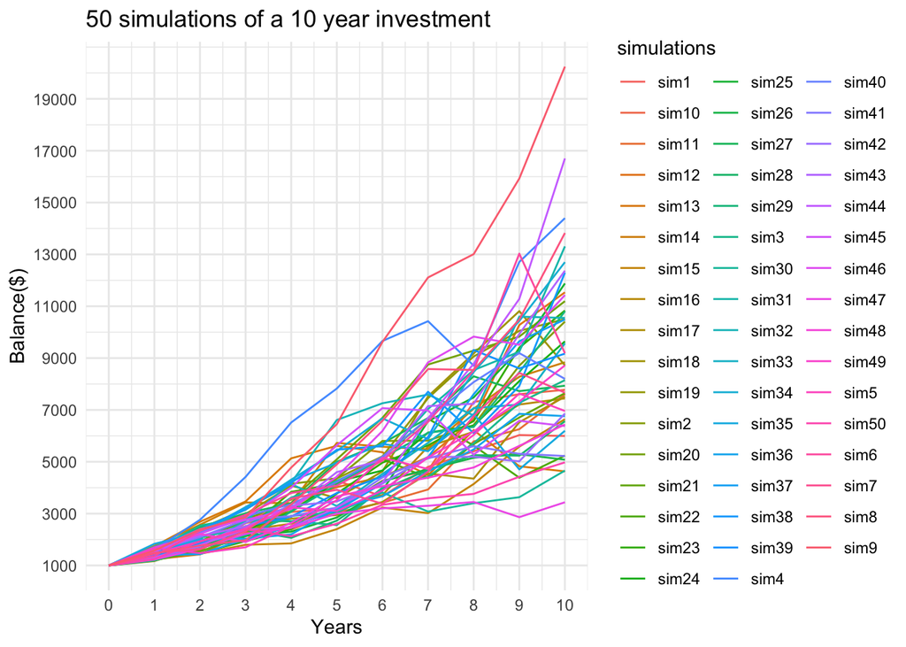

```r
ggplot(data = dat, aes(x= year, y= amount, group=simulation, color =simulation)) +geom_line() +
  labs(title = "50 simulations of a 10 year investment", x ="Years", y="Balance($)") +
  scale_x_continuous(breaks = round(seq(min(dat$year), max(dat$year), by =1),1)) +
  scale_y_continuous(breaks = round(seq(min(dat$amount), max(dat$amount), by=2000), 2000)) +
  guides(color = guide_legend(title="simulations")) +
  theme_minimal()
```

### What things would you add to the graph in order to improve the visualization of so many lines ?

```r
cols <- c("gray","gray","gray","gray","gray","gray","gray","gray","gray","gray", "gray","gray","gray","gray","gray","gray","gray","gray","gray","gray","gray","gray","gray","orange","gray","gray","gray","gray","gray","gray","gray","gray","gray","gray","gray","gray","gray","gray","gray","gray","gray","red","gray","gray","gray","gray","gray","gray","orange","steelblue","gray")

average <- dat %>% filter(year== "10") %>% select(amount) %>% sum/50
```

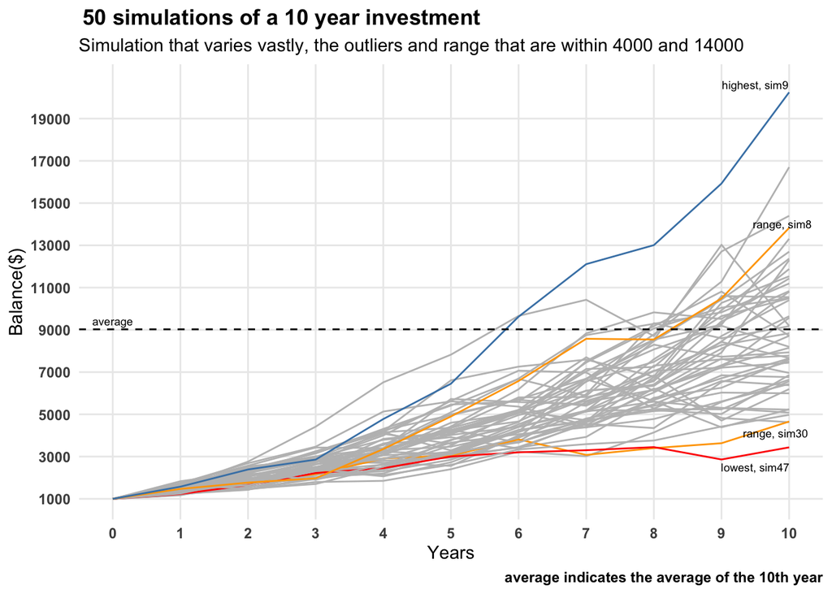

```r
ggplot(data = dat, aes(x= year, y= amount, group=simulation, color=simulation)) +geom_line() +
  labs(title = "50 simulations of a 10 year investment", x ="Years", y="Balance($)", caption="average indicates the average of the 10th year", subtitle ="Simulation that varies vastly, the outliers and range that are within 4000 and 14000") +
  scale_x_continuous(breaks = round(seq(min(dat$year), max(dat$year), by =1),1)) +
  scale_y_continuous(breaks = round(seq(min(dat$amount), max(dat$amount), by=2000), 2000)) +
  scale_color_manual(values=cols) +
  geom_hline(aes(yintercept=average), linetype="dashed") +
  theme_minimal() +
  theme(plot.title = element_text(face="bold", hjust=0.01), plot.caption = element_text(face="bold"), axis.text = element_text(face="bold")) +
  theme(legend.position = "none") +
  theme(panel.grid.minor = element_blank()) +
  annotate(geom="text", x= 9.5, y =20600, label="highest, sim9", size=2.4) +
  annotate(geom="text", x= 9.5, y=2500, label="lowest, sim47", size=2.4) +
  annotate(geom="text", x = 0, y = 9400, label="average", size= 2.4) +
  annotate(geom="text", x= 9.8, y= 4100, label="range, sim30", size=2.4) +
  annotate(geom="text", x=9.9, y= 14000, label="range, sim8", size=2.4)
```